# Project Phase 1

Alex Song

2026-01-26

- instant: record index
- dteday : date c - season : season (1:springer, 2:summer, 3:fall, 4:winter) c - yr : year (0: 2011, 1:2012) c - mnth : month ( 1 to 12) c - holiday : weather day is holiday or not (extracted from http://dchr.dc.gov/page/holiday-schedule) c - weekday : day of the week c - workingday : if day is neither weekend nor holiday is 1, otherwise is 0. c - weathersit :
  - 1: Clear, Few clouds, Partly cloudy, Partly cloudy
  - 2: Mist + Cloudy, Mist + Broken clouds, Mist + Few clouds, Mist
  - 3: Light Snow, Light Rain + Thunderstorm + Scattered clouds, Light Rain + Scattered clouds
  - 4: Heavy Rain + Ice Pallets + Thunderstorm + Mist, Snow + Fog
- temp : Normalized temperature in Celsius. The values are divided to 41 (max)
- atemp: Normalized feeling temperature in Celsius. The values are divided to 50 (max)
- hum: Normalized humidity. The values are divided to 100 (max)
- windspeed: Normalized wind speed. The values are divided to 67 (max)
- casual: count of casual users
- registered: count of registered users
- cnt: count of total rental bikes including both casual and registered

##### Loading and preparing the data

```r
bike <- read.csv("C:/Users/alexm/Desktop/DATA 5321/Project/bike_sharing_daily.csv")
#head(bike)

# Training - 2011 (yr = 0), Test - 2012 (yr = 1)
bike_2011 <- bike %>%
  filter(yr == 0) %>%
  select(-instant, -yr)

bike_2012 <- bike %>%
  filter(yr == 1) %>%
  select(-instant, -yr)

# Factorize categorical variables
cat_vars <- c("season", "mnth", "holiday", "weekday", "workingday", "weathersit")

bike_2011 <- bike_2011 %>%
  mutate(across(all_of(cat_vars), as.factor))

bike_2012 <- bike_2012 %>%
  mutate(across(all_of(cat_vars), as.factor))

#str(bike_2011)
#str(bike_2012)

# temp, atemp, hum, windspeed, casual, registered, cnt
```

## Part 1

**Numerical and Categorical Variable Summary**

```r
# summary statistics for all numeric variables
bike_2011 %>%
  select(where(is.numeric)) %>%
  summary()
```

```
##       temp             atemp              hum           windspeed
##  Min.   :0.05913   Min.   :0.07907   Min.   :0.0000   Min.   :0.02239
##  1st Qu.:0.32500   1st Qu.:0.32195   1st Qu.:0.5383   1st Qu.:0.13558
##  Median :0.47917   Median :0.47285   Median :0.6475   Median :0.18690
##  Mean   :0.48666   Mean   :0.46684   Mean   :0.6437   Mean   :0.19140
##  3rd Qu.:0.65667   3rd Qu.:0.61238   3rd Qu.:0.7421   3rd Qu.:0.23508
##  Max.   :0.84917   Max.   :0.84090   Max.   :0.9725   Max.   :0.50746
##      casual         registered        cnt
##  Min.   :   9.0   Min.   : 416   Min.   : 431
##  1st Qu.: 222.0   1st Qu.:1730   1st Qu.:2132
##  Median : 614.0   Median :2915   Median :3740
##  Mean   : 677.4   Mean   :2728   Mean   :3406
##  3rd Qu.: 871.0   3rd Qu.:3632   3rd Qu.:4586
##  Max.   :3065.0   Max.   :4614   Max.   :6043
```

```r
# frequency table for categorical variables
for (v in cat_vars) {
  cat("\n", v, ":\n", sep = "")
  print(table(bike_2011[[v]]))
}
```

```
##
## season:
##
##  1  2  3  4
## 90 92 94 89
##
## mnth:
##
##  1  2  3  4  5  6  7  8  9 10 11 12
## 31 28 31 30 31 30 31 31 30 31 30 31
##
## holiday:
##
##   0   1
## 355  10
##
## weekday:
##
##  0  1  2  3  4  5  6
## 52 52 52 52 52 52 53
##
## workingday:
##
##   0   1
## 115 250
##
## weathersit:
##
##   1   2   3
## 226 124  15
```

**Correlation Matrix**

```r
# correlation matrix for numerical variables; omitted casual and registered since it's breakdowns of cnt
matrix <- bike_2011 %>%
  select(temp, atemp, hum, windspeed, cnt) %>%
  cor()
round(matrix, 3)
```

```
##             temp  atemp    hum windspeed    cnt
## temp       1.000  0.996  0.146    -0.114  0.771
## atemp      0.996  1.000  0.156    -0.137  0.775
## hum        0.146  0.156  1.000    -0.216  0.002
## windspeed -0.114 -0.137 -0.216     1.000 -0.278
## cnt        0.771  0.775  0.002    -0.278  1.000
```

**Boxplot of Categorical Variables**

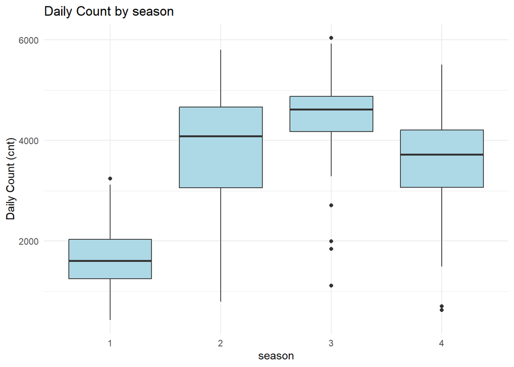

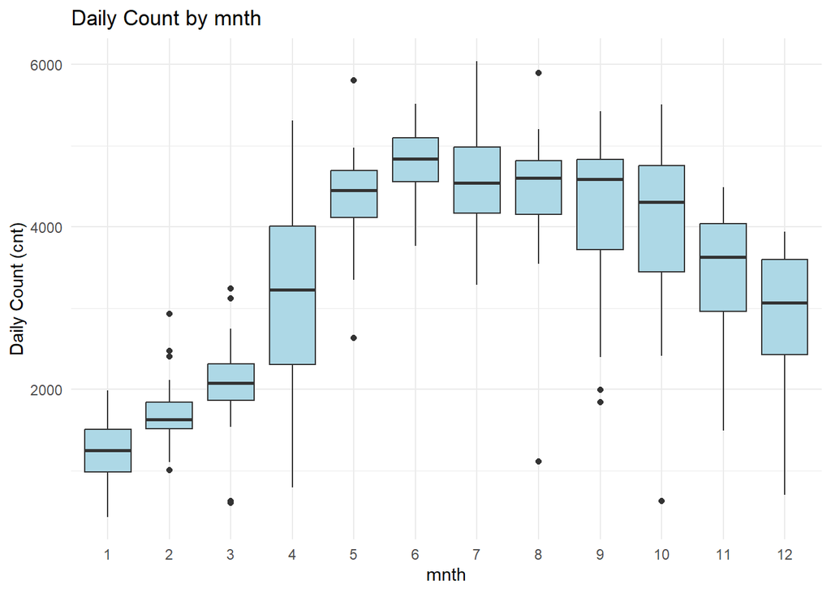

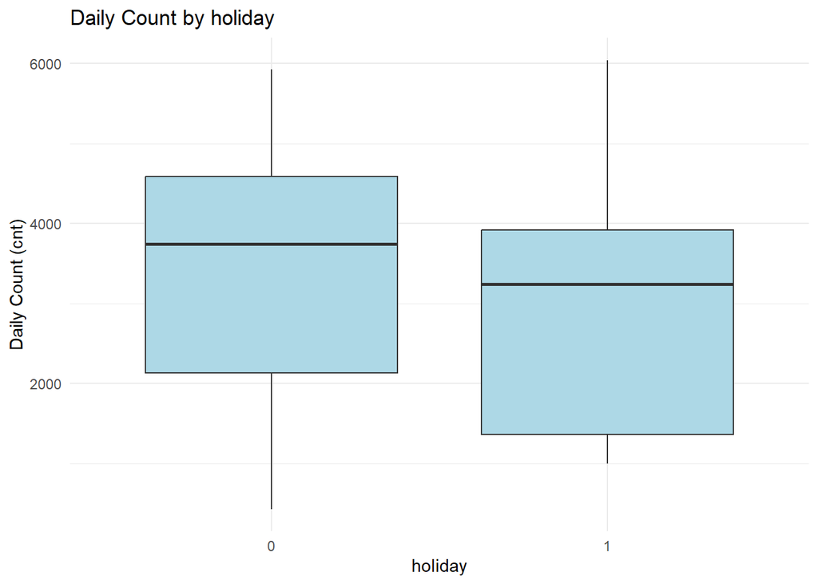

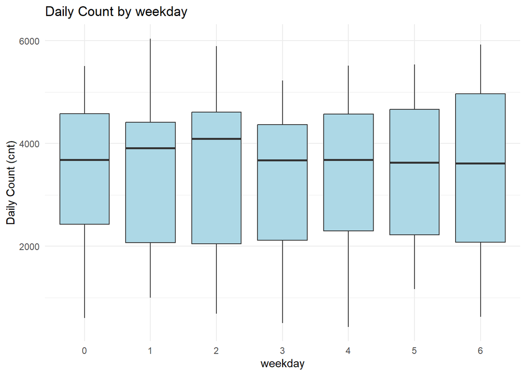

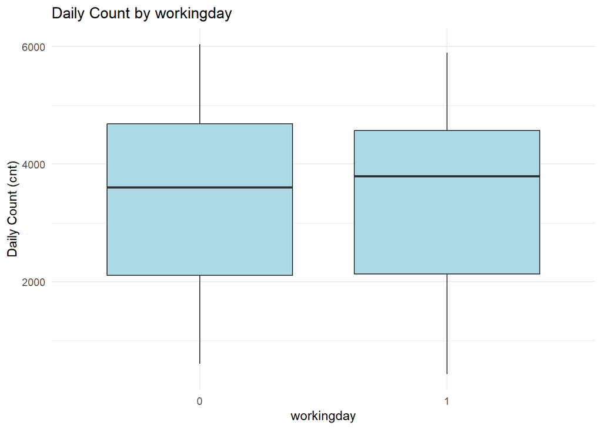

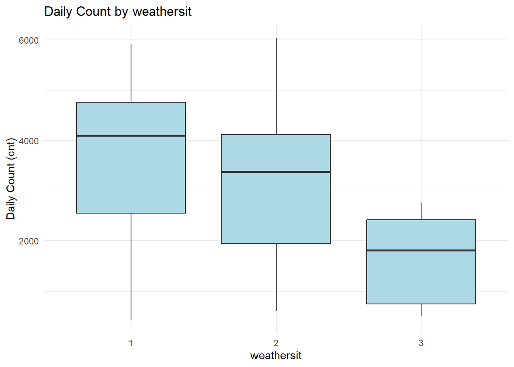

```r
# season, mnth, holiday, weekday, workingday, weathersit
for (v in cat_vars) {
  p <- ggplot(bike_2011, aes_string(x = v, y = "cnt")) +
    geom_boxplot(fill = "lightblue") +
    labs(title = paste("Daily Count by", v),
         x = v, y = "Daily Count (cnt)") +
    theme_minimal()
  print(p)
}
```

**Histogram of Numeric Variables**

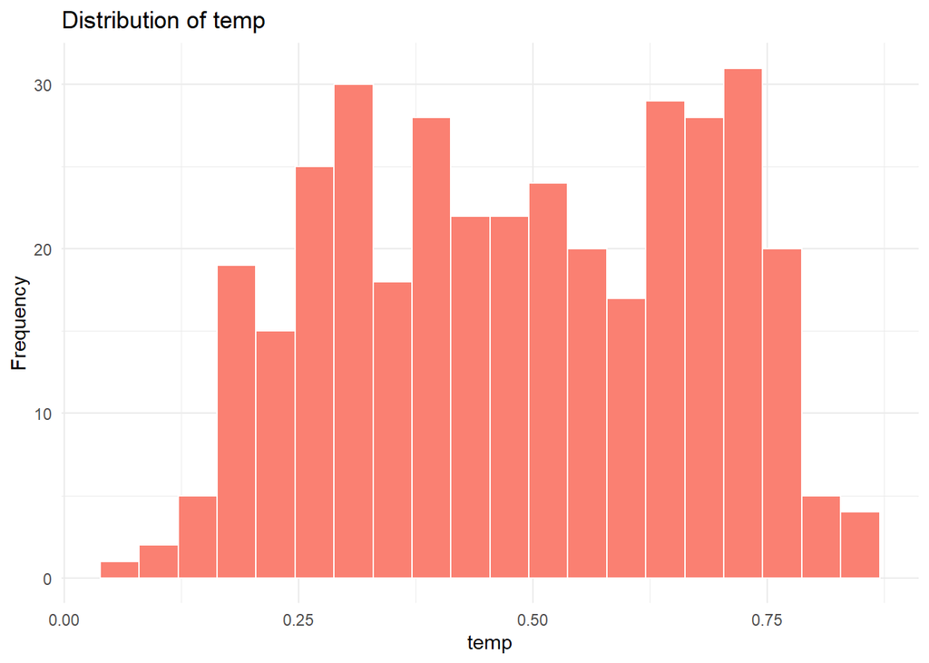

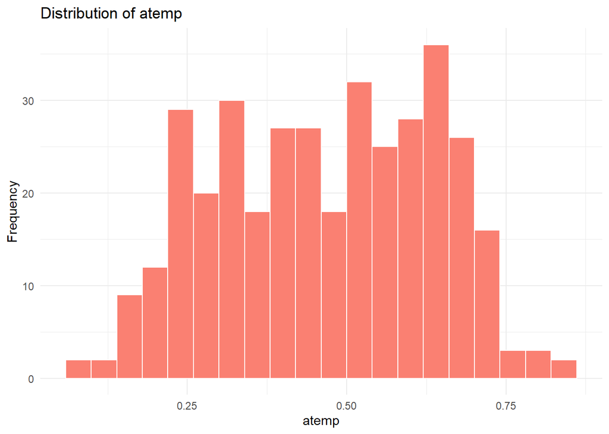

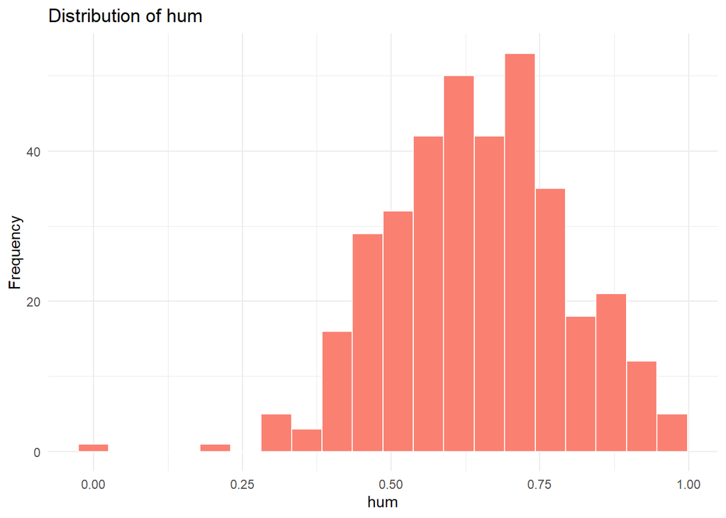

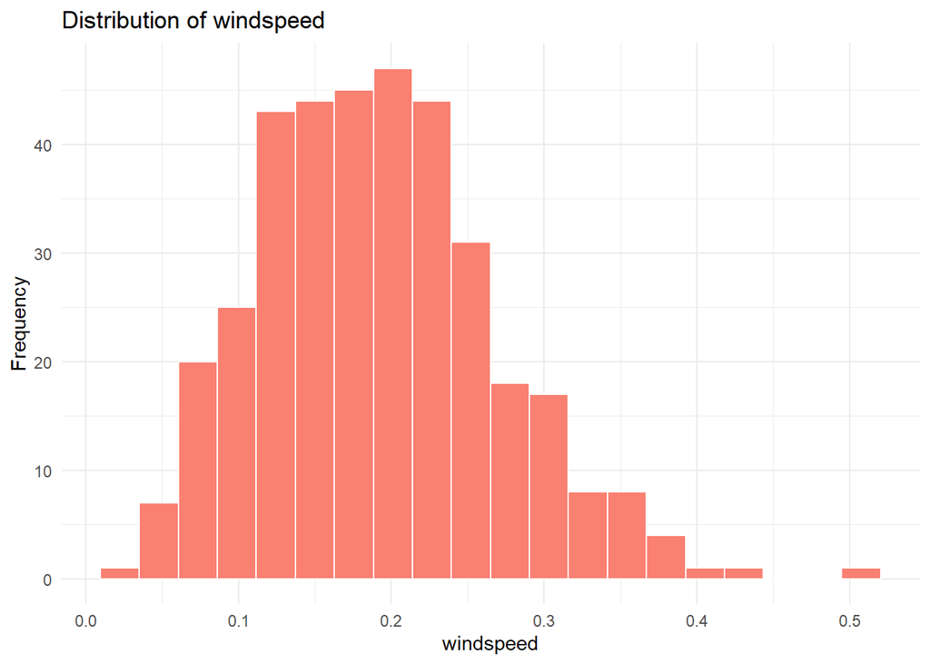

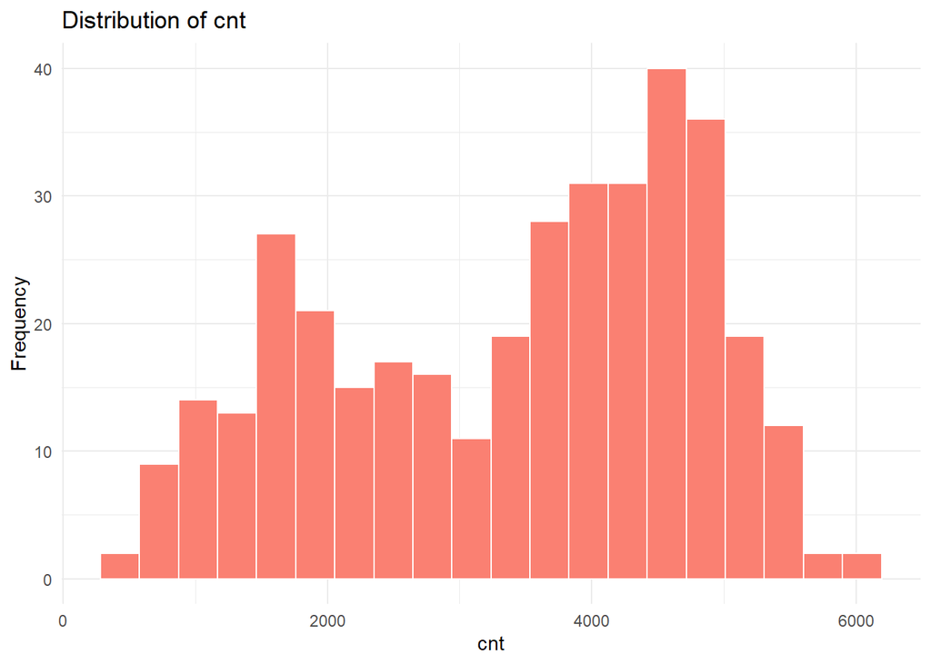

```r
num_vars <- c("temp", "atemp", "hum", "windspeed", "cnt")

for (v in num_vars) {
  p <- ggplot(bike_2011, aes_string(x = v)) +
    geom_histogram(fill = "salmon", color = "white", bins = 20) +
    labs(title = paste("Distribution of", v),
         x = v, y = "Frequency") +
    theme_minimal()
  print(p)
}
```

## Part 2

```r
# Predictors
numeric_preds <- c("temp", "atemp", "hum", "windspeed")
categorical_preds <- c("season", "mnth", "holiday", "weekday", "workingday", "weathersit")
all_preds <- c(categorical_preds, numeric_preds)

# Fit each model
for (i in seq_along(all_preds)) {
  p <- all_preds[i]

  cat("\n", i, ". Regression: cnt ~ ", p, "\n", sep = "")

  model <- lm(reformulate(p, response = "cnt"), data = bike_2011)
  print(summary(model))
}
```

```
##
## 1. Regression: cnt ~ season
##
## Call:
## lm(formula = reformulate(p, response = "cnt"), data = bike_2011)
##
## Residuals:
##     Min      1Q  Median      3Q     Max
## -3349.4  -504.7    96.8   593.6  2029.8
##
## Coefficients:
##             Estimate Std. Error t value Pr(>|t|)
## (Intercept)  1666.67      95.43   17.46   <2e-16 ***
## season2      2108.51     134.23   15.71   <2e-16 ***
## season3      2797.70     133.52   20.95   <2e-16 ***
## season4      1997.79     135.34   14.76   <2e-16 ***
## ---
## Signif. codes:  0 '***' 0.001 '**' 0.01 '*' 0.05 '.' 0.1 ' ' 1
##
## Residual standard error: 905.4 on 361 degrees of freedom
## Multiple R-squared:  0.5724, Adjusted R-squared:  0.5688
## F-statistic: 161.1 on 3 and 361 DF,  p-value: < 2.2e-16
##
##
## 2. Regression: cnt ~ mnth
##
## Call:
## lm(formula = reformulate(p, response = "cnt"), data = bike_2011)
##
## Residuals:
##     Min      1Q  Median      3Q     Max
## -3357.2  -315.2    66.0   479.7  2149.7
##
## Coefficients:
##             Estimate Std. Error t value Pr(>|t|)
## (Intercept)   1231.9      137.6   8.950  < 2e-16 ***
## mnth2          490.1      199.8   2.453   0.0147 *
## mnth3          834.1      194.7   4.285 2.36e-05 ***
## mnth4         1930.4      196.3   9.835  < 2e-16 ***
## mnth5         3149.4      194.7  16.179  < 2e-16 ***
```

[output cut: 172 more lines]

```
##
## Residuals:
##     Min      1Q  Median      3Q     Max
## -3361.4 -1071.1   275.1  1068.4  2601.7
##
## Coefficients:
##             Estimate Std. Error t value Pr(>|t|)
## (Intercept)   4359.9      186.4  23.384  < 2e-16 ***
## windspeed    -4985.0      904.1  -5.514 6.67e-08 ***
## ---
## Signif. codes:  0 '***' 0.001 '**' 0.01 '*' 0.05 '.' 0.1 ' ' 1
##
## Residual standard error: 1326 on 363 degrees of freedom
## Multiple R-squared:  0.07728,    Adjusted R-squared:  0.07474
## F-statistic:  30.4 on 1 and 363 DF,  p-value: 6.673e-08
```

## Part 3

```r
# Model 1 - additive
cat("\nModel 1 (Additive): cnt ~ temp + season\n")
```

```
##
## Model 1 (Additive): cnt ~ temp + season
```

```r
model1a <- lm(cnt ~ temp + season, data = bike_2011)
summary(model1a)
```

```
##
## Call:
## lm(formula = cnt ~ temp + season, data = bike_2011)
##
## Residuals:
##     Min      1Q  Median      3Q     Max
## -3255.0  -421.9   144.6   500.0  1812.0
##
## Coefficients:
##             Estimate Std. Error t value Pr(>|t|)
## (Intercept)    447.8      131.6   3.402 0.000743 ***
## temp          4456.0      378.7  11.767  < 2e-16 ***
## season2        946.7      151.0   6.270 1.03e-09 ***
## season3        892.1      197.8   4.510 8.80e-06 ***
## season4       1316.4      128.9  10.212  < 2e-16 ***
## ---
## Signif. codes:  0 '***' 0.001 '**' 0.01 '*' 0.05 '.' 0.1 ' ' 1
##
## Residual standard error: 770.5 on 360 degrees of freedom
## Multiple R-squared:  0.6912, Adjusted R-squared:  0.6877
## F-statistic: 201.4 on 4 and 360 DF,  p-value: < 2.2e-16
```

```r
# Model 1 - interaction effect
cat("\nModel 1 (Interaction): cnt ~ temp * season\n")
```

```
##
## Model 1 (Interaction): cnt ~ temp * season
```

```r
model1b <- lm(cnt ~ temp * season, data = bike_2011)
summary(model1b)
```

```
##
## Call:
## lm(formula = cnt ~ temp * season, data = bike_2011)
##
## Residuals:
##     Min      1Q  Median      3Q     Max
## -3344.1  -307.4   120.4   438.9  1922.7
##
## Coefficients:
##              Estimate Std. Error t value Pr(>|t|)
## (Intercept)     638.3      237.1   2.691  0.00745 **
## temp           3759.8      818.0   4.596 5.97e-06 ***
## season2        -201.2      388.7  -0.518  0.60507
## season3        3652.7      783.0   4.665 4.37e-06 ***
## season4        1349.2      401.4   3.361  0.00086 ***
## temp:season2   2488.4      990.0   2.513  0.01240 *
## temp:season3  -3512.5     1337.8  -2.626  0.00902 **
## temp:season4    172.8     1100.6   0.157  0.87531
## ---
## Signif. codes:  0 '***' 0.001 '**' 0.01 '*' 0.05 '.' 0.1 ' ' 1
##
## Residual standard error: 745.7 on 357 degrees of freedom
## Multiple R-squared:  0.7131, Adjusted R-squared:  0.7075
## F-statistic: 126.8 on 7 and 357 DF,  p-value: < 2.2e-16
```

```r
# Model 2 - add
cat("\n Model 2 (Additive): cnt ~ temp + weathersit \n")
```

```
##
##  Model 2 (Additive): cnt ~ temp + weathersit
```

```r
model2a <- lm(cnt ~ temp + weathersit, data = bike_2011)
print(summary(model2a))
```

```
##
## Call:
## lm(formula = cnt ~ temp + weathersit, data = bike_2011)
##
## Residuals:
##      Min       1Q   Median       3Q      Max
## -3123.17  -538.67   -19.58   627.54  1764.22
##
## Coefficients:
##             Estimate Std. Error t value Pr(>|t|)
## (Intercept)   975.37     123.02   7.928 2.80e-14 ***
## temp         5444.26     222.05  24.518  < 2e-16 ***
## weathersit2  -439.29      89.65  -4.900 1.45e-06 ***
## weathersit3 -1700.85     213.66  -7.960 2.25e-14 ***
## ---
## Signif. codes:  0 '***' 0.001 '**' 0.01 '*' 0.05 '.' 0.1 ' ' 1
##
## Residual standard error: 799.9 on 361 degrees of freedom
## Multiple R-squared:  0.6662, Adjusted R-squared:  0.6635
## F-statistic: 240.2 on 3 and 361 DF,  p-value: < 2.2e-16
```

```r
# Model 2 - inter
cat("\n Model 2 (Interaction): cnt ~ temp * weathersit \n")
```

```
##
##  Model 2 (Interaction): cnt ~ temp * weathersit
```

```r
model2b <- lm(cnt ~ temp * weathersit, data = bike_2011)
print(summary(model2b))
```

```
##
## Call:
## lm(formula = cnt ~ temp * weathersit, data = bike_2011)
##
## Residuals:
##     Min      1Q  Median      3Q     Max
## -3221.3  -544.7     3.9   625.4  1760.1
##
## Coefficients:
##                  Estimate Std. Error t value Pr(>|t|)
## (Intercept)        1052.1      142.1   7.406 9.38e-13 ***
## temp               5290.6      263.7  20.063  < 2e-16 ***
## weathersit2        -733.7      254.6  -2.882  0.00419 **
## weathersit3       -1279.5      805.0  -1.589  0.11283
## temp:weathersit2    618.0      499.2   1.238  0.21648
## temp:weathersit3   -976.5     1755.4  -0.556  0.57837
## ---
## Signif. codes:  0 '***' 0.001 '**' 0.01 '*' 0.05 '.' 0.1 ' ' 1
##
## Residual standard error: 799.9 on 359 degrees of freedom
## Multiple R-squared:  0.668,  Adjusted R-squared:  0.6634
## F-statistic: 144.5 on 5 and 359 DF,  p-value: < 2.2e-16
```

```r
# Model 3 -add
cat("\n Model 3 (Additive): cnt ~ workingday + weathersit \n")
```

```
##
##  Model 3 (Additive): cnt ~ workingday + weathersit
```

```r
model3a <- lm(cnt ~ workingday + weathersit, data = bike_2011)
print(summary(model3a))
```

```
##
## Call:
## lm(formula = cnt ~ workingday + weathersit, data = bike_2011)
##
## Residuals:
##    Min     1Q Median     3Q    Max
##  -3324  -1098    388   1008   3080
##
## Coefficients:
##             Estimate Std. Error t value Pr(>|t|)
## (Intercept)   3582.9      129.4  27.680  < 2e-16 ***
## workingday1    172.4      147.8   1.166    0.244
## weathersit2   -619.9      146.1  -4.243 2.80e-05 ***
## weathersit3  -2058.1      349.0  -5.898 8.49e-09 ***
## ---
## Signif. codes:  0 '***' 0.001 '**' 0.01 '*' 0.05 '.' 0.1 ' ' 1
##
## Residual standard error: 1303 on 361 degrees of freedom
## Multiple R-squared:  0.1137, Adjusted R-squared:  0.1064
## F-statistic: 15.44 on 3 and 361 DF,  p-value: 1.79e-09
```

```r
# Model 3 - inter
cat("\n Model 3 (Interaction): cnt ~ workingday * weathersit \n")
```

```
##
##  Model 3 (Interaction): cnt ~ workingday * weathersit
```

```r
model3b <- lm(cnt ~ workingday * weathersit, data = bike_2011)
print(summary(model3b))
```

```
##
## Call:
## lm(formula = cnt ~ workingday * weathersit, data = bike_2011)
##
## Residuals:
##     Min      1Q  Median      3Q     Max
## -3323.4 -1113.5   343.8  1003.6  3035.8
##
## Coefficients:
##                         Estimate Std. Error t value Pr(>|t|)
## (Intercept)              3584.47     146.85  24.409  < 2e-16 ***
## workingday1               169.91     182.09   0.933  0.35137
## weathersit2              -577.29     267.72  -2.156  0.03172 *
## weathersit3             -2873.47     934.56  -3.075  0.00227 **
## workingday1:weathersit2   -58.42     319.68  -0.183  0.85509
## workingday1:weathersit3   941.40    1007.99   0.934  0.35097
## ---
## Signif. codes:  0 '***' 0.001 '**' 0.01 '*' 0.05 '.' 0.1 ' ' 1
##
## Residual standard error: 1305 on 359 degrees of freedom
## Multiple R-squared:  0.1161, Adjusted R-squared:  0.1038
## F-statistic:  9.43 on 5 and 359 DF,  p-value: 1.848e-08
```

## Part 4

**Backward Selection**

```r
full_model <- lm(
  cnt ~ season + mnth + holiday + weekday + workingday +
    weathersit + temp + atemp + hum + windspeed +
    temp:season + temp:weathersit + workingday:weathersit,
  data = bike_2011
)

cat("\n Full Model \n")
```

```
##
##  Full Model
```

```r
print(summary(full_model))
```

```
##
## Call:
## lm(formula = cnt ~ season + mnth + holiday + weekday + workingday +
##     weathersit + temp + atemp + hum + windspeed + temp:season +
##     temp:weathersit + workingday:weathersit, data = bike_2011)
##
## Residuals:
##      Min       1Q   Median       3Q      Max
## -2479.21  -224.12    27.87   300.74  1942.49
##
## Coefficients: (1 not defined because of singularities)
##                         Estimate Std. Error t value Pr(>|t|)
## (Intercept)              1696.55     257.60   6.586 1.78e-10 ***
## season2                   224.19     397.55   0.564 0.573192
## season3                  7082.16     847.13   8.360 1.78e-15 ***
## season4                   893.79     426.86   2.094 0.037036 *
## mnth2                     160.59     151.79   1.058 0.290853
## mnth3                     304.22     185.32   1.642 0.101637
## mnth4                     865.41     260.70   3.320 0.001002 **
## mnth5                    1461.45     282.38   5.176 3.96e-07 ***
## mnth6                    1070.23     314.14   3.407 0.000738 ***
## mnth7                     755.57     347.76   2.173 0.030513 *
## mnth8                     455.92     335.69   1.358 0.175334
## mnth9                     252.28     322.61   0.782 0.434775
## mnth10                    519.27     264.54   1.963 0.050498 .
## mnth11                    219.62     254.00   0.865 0.387873
## mnth12                    369.07     211.11   1.748 0.081354 .
## holiday1                 -408.59     186.76  -2.188 0.029382 *
## weekday1                   78.27     111.20   0.704 0.481977
## weekday2                  129.79     112.71   1.152 0.250350
## weekday3                  106.40     113.21   0.940 0.347959
## weekday4                   95.12     112.04   0.849 0.396489
## weekday5                  152.71     112.59   1.356 0.175934
## weekday6                  146.89     103.83   1.415 0.158095
## workingday1                   NA         NA      NA       NA
## weathersit2               -49.92     204.14  -0.245 0.806950
## weathersit3              -507.40     602.58  -0.842 0.400372
## temp                     5812.28    2410.63   2.411 0.016450 *
## atemp                   -1954.83    2355.84  -0.830 0.407262
## hum                     -1299.14     277.43  -4.683 4.14e-06 ***
## windspeed               -2186.19     436.83  -5.005 9.12e-07 ***
## season2:temp              193.70    1007.33   0.192 0.847637
## season3:temp            -9069.42    1385.20  -6.547 2.24e-10 ***
## season4:temp             1188.93    1112.17   1.069 0.285839
## weathersit2:temp         -521.60     346.36  -1.506 0.133035
## weathersit3:temp        -4421.44    1253.63  -3.527 0.000480 ***
## workingday1:weathersit2   -79.94     132.37  -0.604 0.546301
## workingday1:weathersit3   825.87     453.83   1.820 0.069698 .
## ---
## Signif. codes:  0 '***' 0.001 '**' 0.01 '*' 0.05 '.' 0.1 ' ' 1
##
## Residual standard error: 522.4 on 330 degrees of freedom
## Multiple R-squared:  0.8699, Adjusted R-squared:  0.8564
## F-statistic: 64.87 on 34 and 330 DF,  p-value: < 2.2e-16
```

```r
# Backward selection
cat("\n Final Model \n")
```

```
##
##  Final Model
```

```r
final_model <- step(full_model, direction = "backward")
```

```
## Start:  AIC=4601.85
## cnt ~ season + mnth + holiday + weekday + workingday + weathersit +
##     temp + atemp + hum + windspeed + temp:season + temp:weathersit +
##     workingday:weathersit
##
##
## Step:  AIC=4601.85
## cnt ~ season + mnth + weekday + workingday + weathersit + temp +
##     atemp + hum + windspeed + season:temp + weathersit:temp +
##     workingday:weathersit
##
##                         Df Sum of Sq       RSS    AIC
## - weekday                6   2003143  92057860 4597.9
## - atemp                  1    187898  90242615 4600.6
## <none>                                90054717 4601.9
## - workingday:weathersit  2   1091812  91146530 4602.2
## - weathersit:temp        2   3729758  93784475 4612.7
## - hum                    1   5984121  96038838 4623.3
## - windspeed              1   6835140  96889857 4626.6
## - mnth                  11  14375262 104429979 4633.9
## - season:temp            3  16604640 106659357 4657.6
##
## Step:  AIC=4597.88
## cnt ~ season + mnth + workingday + weathersit + temp + atemp +
##     hum + windspeed + season:temp + weathersit:temp + workingday:weathersit
##
##                         Df Sum of Sq       RSS    AIC
## - atemp                  1     85076  92142936 4596.2
## - workingday:weathersit  2    829542  92887402 4597.2
## <none>                                92057860 4597.9
## - weathersit:temp        2   3813492  95871352 4608.7
## - hum                    1   6088264  98146124 4619.3
## - windspeed              1   6576760  98634620 4621.1
## - mnth                  11  14667076 106724936 4629.8
## - season:temp            3  16701339 108759199 4652.7
##
## Step:  AIC=4596.22
## cnt ~ season + mnth + workingday + weathersit + temp + hum +
##     windspeed + season:temp + weathersit:temp + workingday:weathersit
##
```

[output cut: 18 more lines]

```
## - windspeed        1   7375477 100333360 4621.3
## - mnth            11  14218104 107175988 4625.4
## - season:temp      3  17457297 110415181 4652.2
##
## Step:  AIC=4594.46
## cnt ~ season + mnth + weathersit + temp + hum + windspeed + season:temp +
##     weathersit:temp
##
##                   Df Sum of Sq       RSS    AIC
## <none>                          93219817 4594.5
## - weathersit:temp  2   3222761  96442578 4602.9
## - hum              1   6752984  99972801 4618.0
## - windspeed        1   7378358 100598174 4620.3
## - mnth            11  14162401 107382218 4624.1
## - season:temp      3  17646415 110866232 4651.7
```

```r
print(summary(final_model))
```

```
##
## Call:
## lm(formula = cnt ~ season + mnth + weathersit + temp + hum +
##     windspeed + season:temp + weathersit:temp, data = bike_2011)
##
## Residuals:
##      Min       1Q   Median       3Q      Max
## -2380.68  -256.92    33.41   302.32  1681.24
##
## Coefficients:
##                  Estimate Std. Error t value Pr(>|t|)
## (Intercept)       1756.97     238.69   7.361 1.39e-12 ***
## season2            233.69     387.60   0.603 0.546967
## season3           7182.36     836.97   8.581 3.39e-16 ***
## season4            812.64     411.10   1.977 0.048881 *
## mnth2              148.79     151.35   0.983 0.326259
## mnth3              319.42     183.83   1.738 0.083187 .
## mnth4              820.82     256.95   3.194 0.001532 **
## mnth5             1447.28     278.72   5.193 3.58e-07 ***
## mnth6             1086.13     305.80   3.552 0.000437 ***
## mnth7              751.35     339.17   2.215 0.027404 *
## mnth8              476.98     325.11   1.467 0.143261
## mnth9              233.85     309.95   0.754 0.451083
## mnth10             421.02     260.13   1.618 0.106485
## mnth11             152.51     251.45   0.607 0.544573
## mnth12             345.35     209.28   1.650 0.099831 .
## weathersit2        -53.79     177.79  -0.303 0.762444
## weathersit3        -48.09     553.09  -0.087 0.930767
## temp              3997.94     747.02   5.352 1.60e-07 ***
## hum              -1347.14     271.44  -4.963 1.10e-06 ***
## windspeed        -2138.02     412.14  -5.188 3.67e-07 ***
## season2:temp       234.73     964.34   0.243 0.807832
## season3:temp     -9144.38    1354.99  -6.749 6.45e-11 ***
## season4:temp      1529.10    1051.56   1.454 0.146832
## weathersit2:temp  -616.34     341.37  -1.806 0.071881 .
## weathersit3:temp -3732.47    1198.38  -3.115 0.001998 **
## ---
## Signif. codes:  0 '***' 0.001 '**' 0.01 '*' 0.05 '.' 0.1 ' ' 1
##
## Residual standard error: 523.6 on 340 degrees of freedom
## Multiple R-squared:  0.8653, Adjusted R-squared:  0.8558
## F-statistic: 90.99 on 24 and 340 DF,  p-value: < 2.2e-16
```

## Part 5

**Model Performance: Training vs Test**

```r
# Training metrics for comparison
rmse_2011 <- sqrt(mean(residuals(final_model)^2))
mae_2011 <- mean(abs(residuals(final_model)))

# Predictions for 2012
bike_2012$pred_cnt <- predict(final_model, newdata = bike_2012)
bike_2012$resid <- bike_2012$cnt - bike_2012$pred_cnt

# Performance metrics
rmse_2012 <- sqrt(mean(bike_2012$resid^2))
mae_2012  <- mean(abs(bike_2012$resid))

cat("Model Performance on 2012: Test Data\n")
```

```
## Model Performance on 2012: Test Data
```

```r
cat("RMSE :", round(rmse_2012, 2), "\n")
```

```
## RMSE : 2283.22
```

```r
cat("MAE  :", round(mae_2012, 2), "\n")
```

```
## MAE  : 2114.76
```

```r
cat("\nComparison with 2011 v 2012 Data\n")
```

```
##
## Comparison with 2011 v 2012 Data
```

```r
cat("Training RMSE (2011) :", round(rmse_2011, 2), "\n")
```

```
## Training RMSE (2011) : 505.37
```

```r
cat("Test RMSE (2012)     :", round(rmse_2012, 2), "\n")
```

```
## Test RMSE (2012)     : 2283.22
```

```r
cat("Difference           :", round(rmse_2012 - rmse_2011, 2), "\n")
```

```
## Difference           : 1777.85
```

```r
cat("\n")
```

```r
cat("Training MAE (2011) :", round(mae_2011, 2), "\n")
```

```
## Training MAE (2011) : 372.23
```

```r
cat("Test MAE (2012)     :", round(mae_2012, 2), "\n")
```

```
## Test MAE (2012)     : 2114.76
```

```r
cat("Difference          :", round(mae_2012 - mae_2011, 2), "\n")
```

```
## Difference          : 1742.53
```

**Observed vs Predicted:**

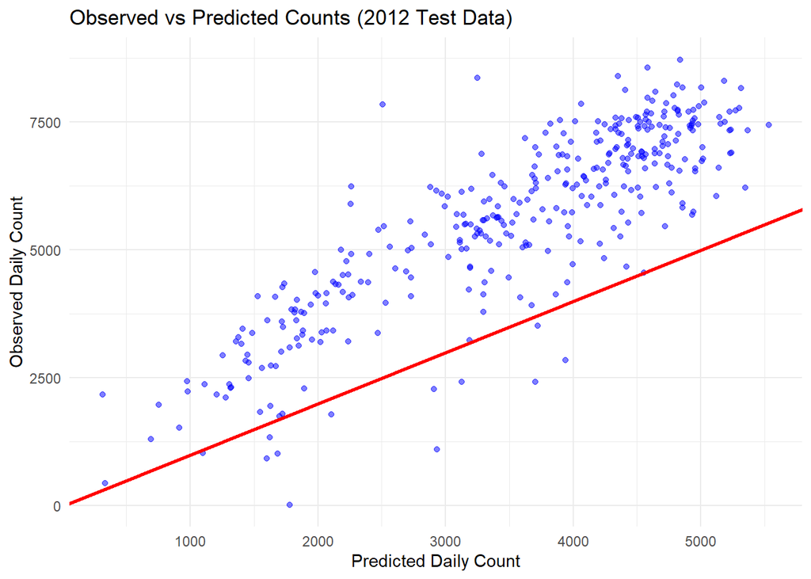

```r
ggplot(bike_2012, aes(x = pred_cnt, y = cnt)) +
  geom_point(alpha = 0.5, color = "blue") +
  geom_abline(slope = 1, intercept = 0, color = "red", linewidth = 1) +
  labs(title = "Observed vs Predicted Counts (2012 Test Data)",
       x = "Predicted Daily Count",
       y = "Observed Daily Count") +
  theme_minimal()
```